# Federal Judicial Center Dashboard

[figure not shown]

[figure not shown]

[figure not shown]

[figure not shown]

[figure not shown]

# Welcome

Welcome to the Federal Judicial Center Dashboard!

The Federal Judicial Center is the agency within the judicial branch of the U.S. government tasked with examining federal court practices and policies. Among the information it shares with the public is the [Integrated Data Base](https://www.fjc.gov/research/idb), a repository of data on all federal courts.

The database of federal civil court cases between 1988 and the present is available for download as a [tab-delimited file](https://www.fjc.gov/research/idb/civil-cases-filed-terminated-and-pending-sy-1988-present) on the Federal Judicial Center’s website.

This customized dashboard was created on 2020-03-15.

To make your own custom dashboard, visit the [Federal Judicial Center Dashboard project repository on GitHub](https://github.com/DiPierro/federal-judicial-center).

Disclaimers:

- This dashboard is not a product of the Federal Judicial Center.
- This dashboard is a work in progress. Check back for updates and improvements.
- The data presented here have been de-duplicated and cleaned at a basic level, but may still include duplicate cases and other errors. Plaintiff and defendant names have not been standardized.

For questions, comments and bugs, contact dipierro@stanford.edu.

# By context

## Most-common types of lawsuits in New Jersey

### Most-common types of lawsuits in New Jersey

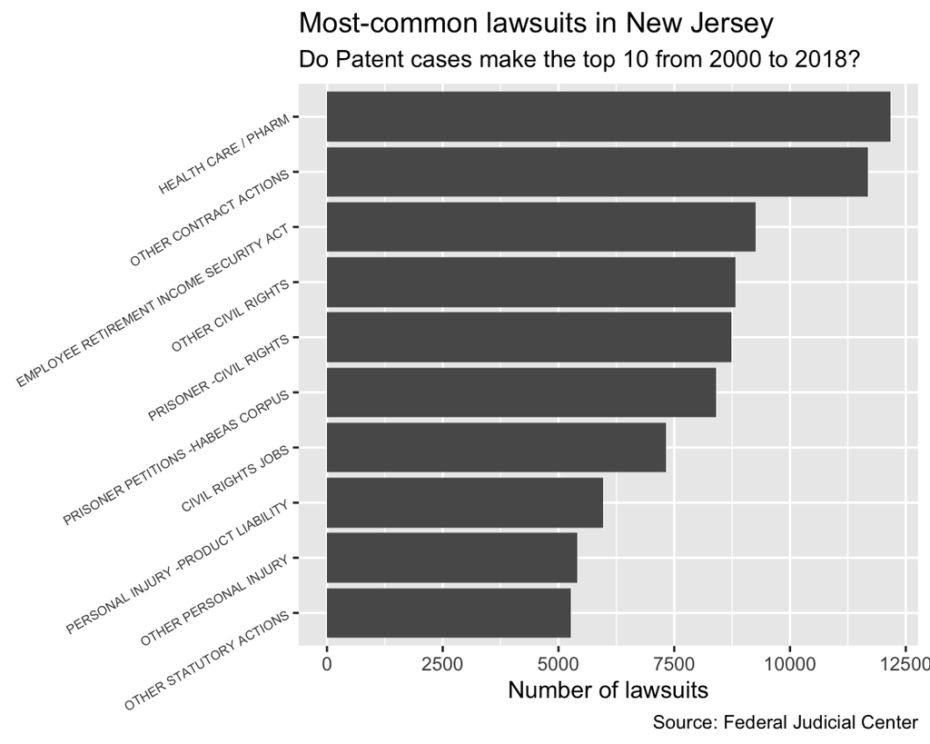

## Most common types of lawsuits in all district courts, 2000 to 2018

### Most common types of lawsuits in all district courts, 2000 to 2018

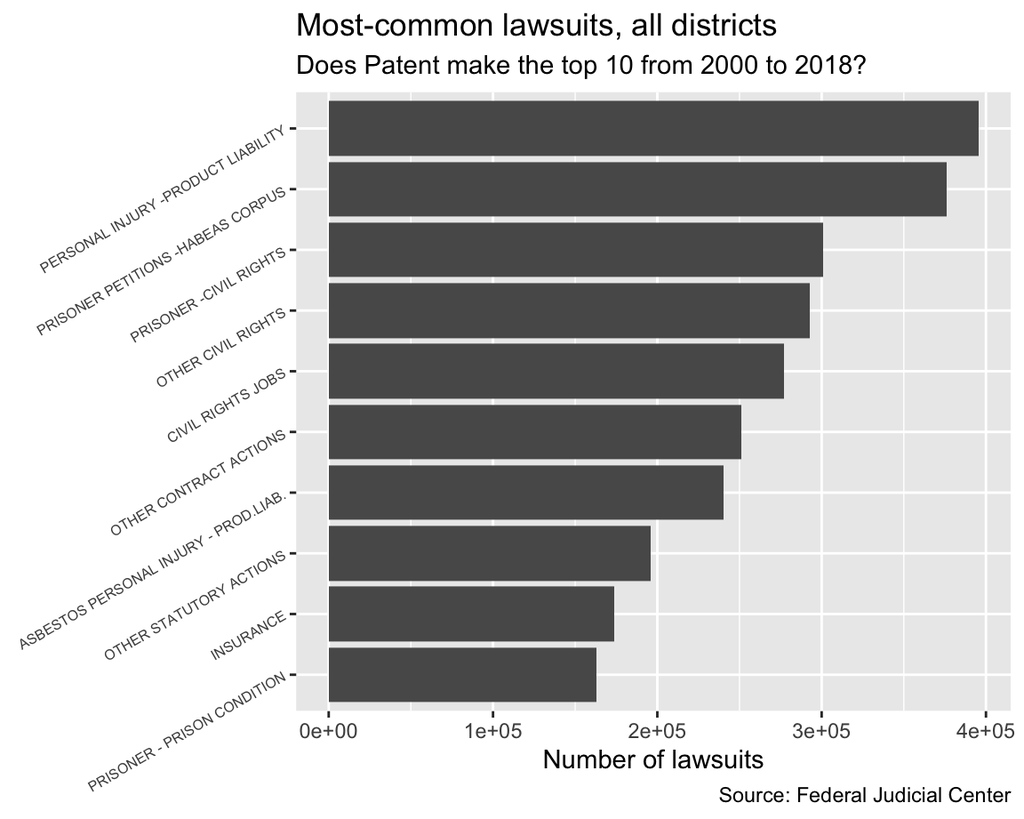

# By year

## Change in all cases types

### Change in all cases types

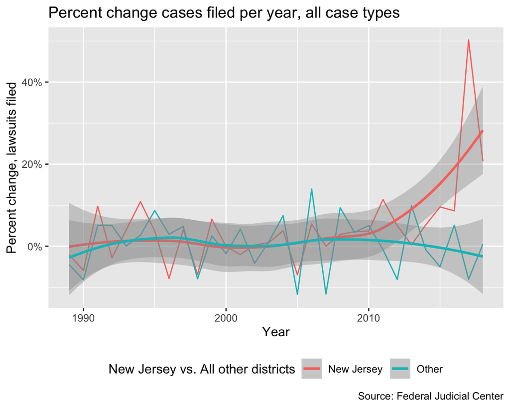

## Change in Patent cases

### Change in Patent cases

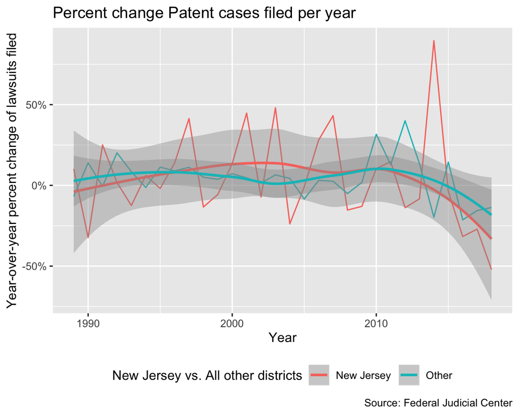

# By district

## How New Jersey compares on Patent cases, 2000 to 2018

### How New Jersey compares on Patent cases, 2000 to 2018

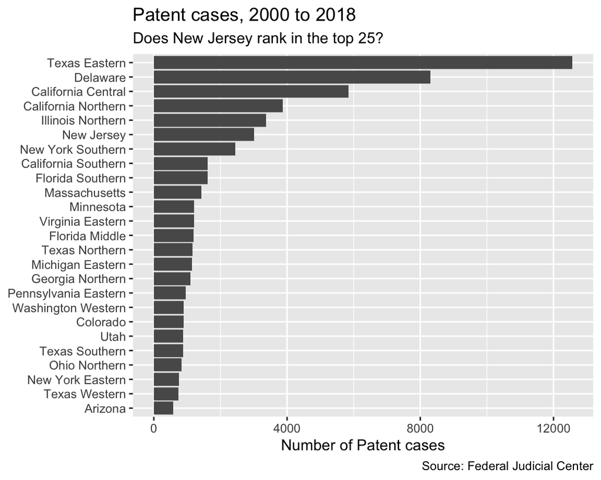

## How New Jersey compares on Patent cases, 2000 to 2018

### How New Jersey compares on Patent cases, 2000 to 2018

|  | District | Count |
| --- | --- | --- |
| 1 | Texas Eastern | 12568 |
| 2 | Delaware | 8299 |
| 3 | California Central | 5838 |
| 4 | California Northern | 3871 |
| 5 | Illinois Northern | 3375 |
| 6 | New Jersey | 3013 |
| 7 | New York Southern | 2452 |
| 8 | California Southern | 1617 |
| 9 | Florida Southern | 1614 |
| 10 | Massachusetts | 1431 |

[output cut: 83 more lines]

# By plaintiff and defendant

## Most-common Patent plaintiffs from 2000 to 2018 in the New Jersey district

### Most-common Patent plaintiffs from 2000 to 2018 in the New Jersey district

|  | Plaintiff | Count |
| --- | --- | --- |
| 1 | OTSUKA PHARMACEUTICAL CO., LTD | 80 |
| 2 | RICHMOND | 68 |
| 3 | ASTRAZENECA AB, ET AL | 45 |
| 4 | SCHERING CORPORATION | 36 |
| 5 | ASTRAZENECA PHARMACEUTI, ET AL | 34 |
| 6 | SANOFI-AVENTIS U.S. LLC, ET AL | 34 |
| 7 | HORIZON PHARMA IRELAND , ET AL | 30 |
| 8 | PFIZER INC., ET AL | 30 |
| 9 | NOVARTIS PHARMACEUTICALS CORPO | 27 |
| 10 | TEVA PHARMACEUTICAL INDUSTRIES | 24 |

[output cut: 1309 more lines]

## Most-common Patent defendants from 2000 to 2018 in the New Jersey district

### Most-common Patent defendants from 2000 to 2018 in the New Jersey district

|  | Defendant | Count |
| --- | --- | --- |
| 1 | DR. REDDY'S LABORATORIE, ET AL | 57 |
| 2 | SANDOZ INC. | 36 |
| 3 | TEVA PHARMACEUTICALS US, ET AL | 35 |
| 4 | TEVA PHARMACEUTICALS USA, INC. | 29 |
| 5 | ACTAVIS LABORATORIES FL, ET AL | 27 |
| 6 | MYLAN PHARMACEUTICALS I, ET AL | 25 |
| 7 | WATSON LABORATORIES, IN, ET AL | 22 |
| 8 | LUPIN LTD., ET AL | 21 |
| 9 | SANDOZ, INC. | 21 |
| 10 | ROXANE LABORATORIES, INC. | 20 |

[output cut: 1831 more lines]

# By county

### Top five counties in New Jersey for Patent litigation

[figure not shown]

## Number of Patent lawsuits per 1,000 people in New Jersey by county

### Number of Patent lawsuits per 1,000 people in New Jersey by county

|  | Lawsuits per 1,000 people | County |
| --- | --- | --- |
| 1 | 1.26944680517094 | Mercer |
| 2 | 0.685418330913391 | Somerset |
| 3 | 0.638034380250959 | Morris |
| 4 | 0.549996111519366 | Essex |
| 5 | 0.391831721276735 | Bergen |
| 6 | 0.34827059174508 | Atlantic |
| 7 | 0.311596853329277 | Middlesex |
| 8 | 0.253144216804178 | Hunterdon |
| 9 | 0.24540456916435 | Union |
| 10 | 0.23779942063089 | Camden |

[output cut: 11 more lines]